# Evolução das Técnicas de Amostragem (1975-2025)

238719

2025-10-23

## **RESUMO EXECUTIVO**

**Este trabalho analisa a evolução das técnicas de amostragem ao longo dos últimos 50 anos (1975-2025),** simulando como o **declínio nas taxas de resposta** e o **desenvolvimento de métodos estatísticos mais sofisticados** impactaram a **qualidade das estimativas** em pesquisas por amostragem.

## **INTRODUÇÃO**

**Baseado no artigo “Survey sampling during the last 50 years”**, este estudo simula a **evolução histórica dos métodos de amostragem**, com foco em:

### **PRINCIPAIS TEMAS ANALISADOS:**

- **Declínio das taxas de resposta** ao longo do tempo
- **Desenvolvimento de estimadores assistidos por modelo (GREG)**
- **Impacto na qualidade das estimativas**
- **Evolução da estimação de variância**
- **Crescimento das amostras não-probabilísticas**

## **METODOLOGIA**

### **POPULAÇÃO E AMOSTRA**

- **Período**: 1975-2025 (50 anos)
- **População simulada**: 5.000 indivíduos por ano
- **Amostra alvo**: 300 indivíduos por ano

### **VARIÁVEIS ANALISADAS:**

- **X** (variável auxiliar, ex: renda)
- **Y** (variável de interesse, correlacionada com X)

### **MÉTODOS DE ESTIMAÇÃO COMPARADOS:**

- **Média Simples**: Estimador tradicional
- **Regressão (GREG)**: Estimador assistido por modelo

## **RESULTADOS E ANÁLISE**

### **1. EVOLUÇÃO DA TAXA DE RESPOSTA**

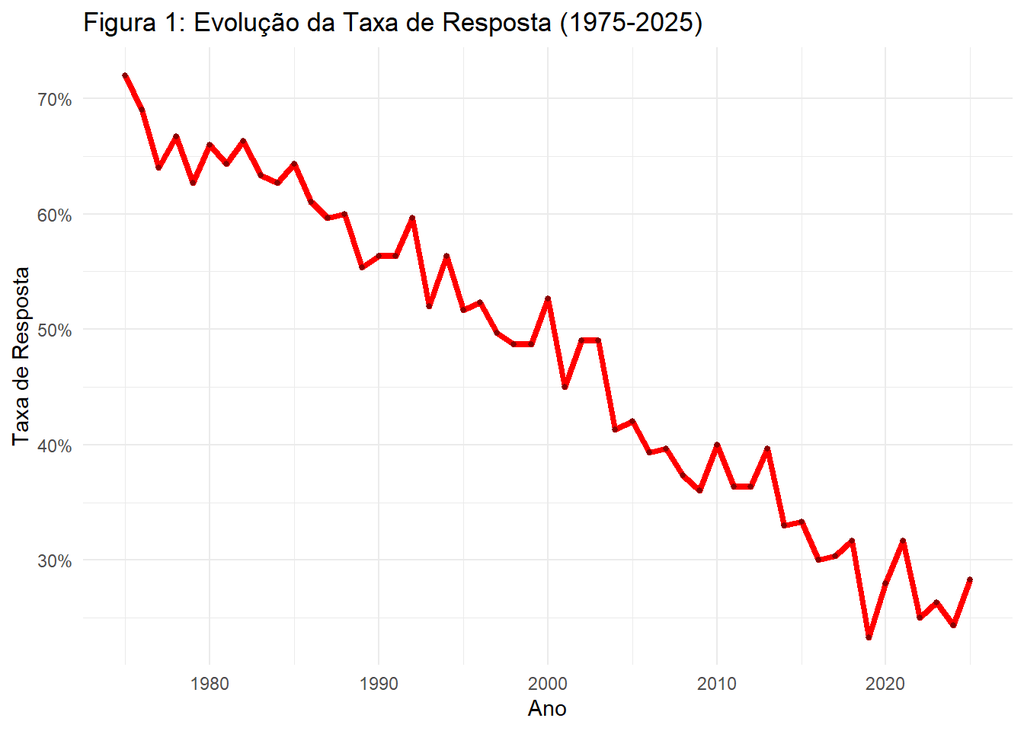

**ANÁLISE**: Observa-se um **declínio consistente nas taxas de resposta**, indo de aproximadamente **72% em 1975** para cerca de **28.3% em 2025**.

### **2. COMPARAÇÃO DO VIÉS DOS ESTIMADORES**

2. Comparação do Viés dos Estimadores

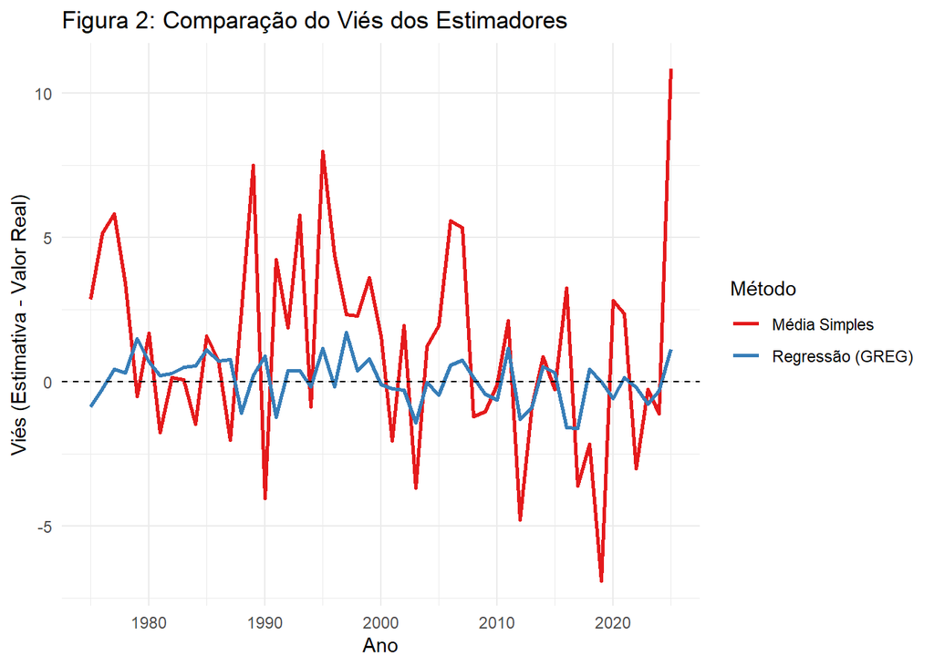

### **3. MÉTODOS DE ESTIMAÇÃO AO LONGO DO TEMPO**

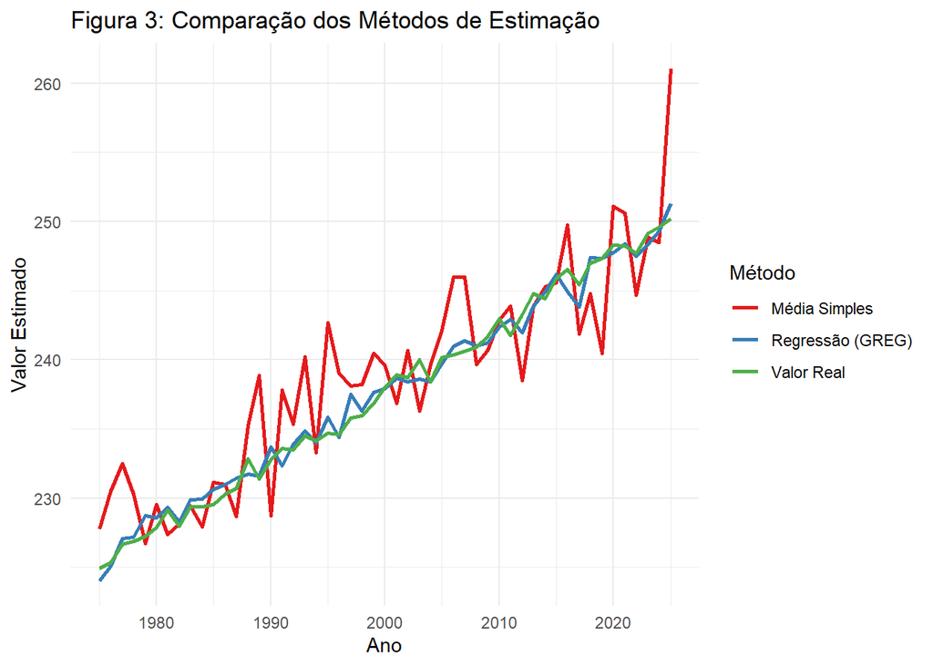

**ANÁLISE**: O **GREG acompanha mais de perto o valor real**, enquanto a **média simples apresenta desvios consistentes**.

## **ANÁLISE POR DÉCADA**

Tabela 1: Métricas por Década

| decada | Taxa_Resposta_Media | Vies_Medio_Simples | Vies_Medio_GREG | Melhoramento |
| --- | --- | --- | --- | --- |
| 1970 | 66.9% | 3.542 | 0.668 | 81.1% |
| 1980 | 62.3% | 1.935 | 0.609 | 68.5% |
| 1990 | 53.2% | 3.734 | 0.724 | 80.6% |
| 2000 | 43.1% | 2.557 | 0.448 | 82.5% |
| 2010 | 33.4% | 2.493 | 0.847 | 66% |
| 2020 | 27.3% | 3.398 | 0.520 | 84.7% |

## **PRINCIPAIS CONCLUSÕES**

### **SUPERIORIDADE DO GREG**

O **estimador GREG mostrou-se consistentemente superior**, com **redução média de 77.5% no viés** comparado à média simples.

## Estimação de Variância por Métodos de Replicação

A evolução computacional dos últimos 50 anos revolucionou a estimação de variância em amostragem. Enquanto nas décadas iniciais dependíamos de fórmulas analíticas complexas e limitadas a desenhos amostrais simples, o aumento do poder computacional permitiu o desenvolvimento de **métodos de replicação** como:

- **Bootstrap**: Reamostragem para estimar distribuição amostral
- **Jackknife**: Eliminação sistemática de observações
- **Balanced half-samples**: Divisão balanceada da amostra

Estes métodos são particularmente valiosos para desenhos amostrais complexos, onde derivações analíticas seriam impraticáveis. Sua implementação em softwares como R (pacote `survey`) democratizou o acesso a estimações de variância robustas.

## Amostras Não-Probabilísticas: Desafios e Oportunidades

O panorama atual da amostragem é marcado pelo crescimento explosivo das **amostras não-probabilísticas**:

**Fontes Emergentes:** - **Big Data** e registros administrativos - **Pesquisas online** opt-in - **Dados digitais** de plataformas

**Vantagens:** - **Custo reduzido** comparado a pesquisas tradicionais - **Velocidade** na obtenção dos dados - **Grandes volumes** de informação

**Desafios Críticos:** - **Viés de seleção** desconhecido e potencialmente grande - **Probabilidades de inclusão** desconhecidas - **Dificuldade** em validar representatividade

**Abordagens Promissoras:** - **Combinação** com amostras probabilísticas - **Métodos doubly robust** para correção de viés - **Estimação** de probabilidades de inclusão - **Ponderação** por escore de propensão

## Tendências Futuras e Considerações Finais

A evolução da amostragem nos últimos 50 anos aponta para direções claras:

### **Transformações em Curso:**

1. **Integração de Fontes**: Combinação de dados probabilísticos e não-probabilísticos
2. **Automação**: Processos amostrais cada vez mais automatizados
3. **Personalização**: Desenhos adaptativos baseados em aprendizado de máquina
4. **Abordagens Híbridas**: Métodos que transcendem a dicotomia probabilístico/não-probabilístico

### **Lições dos Últimos 50 Anos:**

- A **adaptabilidade** é essencial frente a mudanças tecnológicas e sociais
- Métodos **assistidos por modelo** comprovaram seu valor na prática
- O **declínio das taxas de resposta** exigiu inovação constante
- A **revolução computacional** democratizou métodos sofisticados

### **Visão para o Futuro:**

A amostragem continuará evoluindo, com ênfase crescente em métodos robustos para integração de dados múltiplos, abordagens que balanceiem viés e variância, e frameworks que acomodem a riqueza de novas fontes de dados enquanto mantêm rigor inferencial.

**Referências** de Waal, T., & Scholtus, S. (2023). Survey sampling during the last 50 years. The Survey Statistician.

Lumley, T. (2010). Complex Surveys: A Guide to Analysis Using R. Wiley.

Trabalho acadêmico desenvolvido para a disciplina Técnicas de Amostragem.